# Lightroom

Benjamin Wagner

08.07.2022

Der Import und die Verwaltung deiner Bilder stellen einen nicht weniger wichtigen Teil deiner Arbeit dar. Diesen solltest du daher nicht vernachlässigen. Um dir den Einstieg in Lightroom so leicht wie möglich zu machen, zeige ich dir, wie ich arbeite. Es muss nicht zwingend die beste Herangehensweise sein und vielleicht würdest du einiges sogar ganz anders machen, aber zumindest kannst du dir einen ersten Eindruck davon machen, wie du es machen könntest. Für deine Tipps und Verbesserungsvorschläge habe ich immer ein offenens Ohr.

## Katalog anlegen

Wir starten mit einem frischen Katalog. Diesen legen wir über das Menü an.

[figure not shown]

neuen Katalog erstellen

## Bilder importieren

Bevor es an die Nachbearbeitung deiner Bilder geht. gilt es zunächst, diese zu importieren. Am besten so, dass du sie später schnell und einfach wiederfindest.

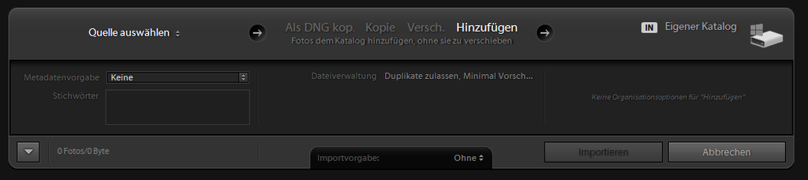

einfacher Importdialog

Wenn dir nur der einfache Importdialog angezeigt wird, kannst du ihn erweitern, indem du auf den Pfeil unten links klickst.

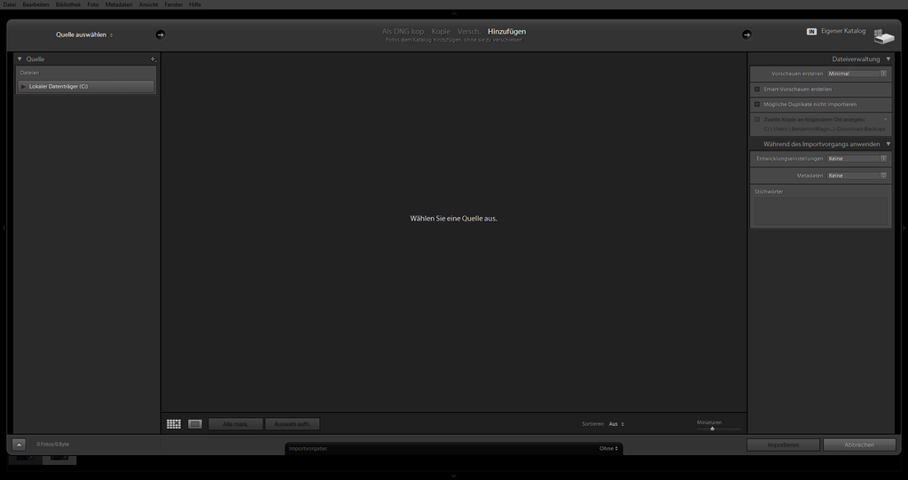

erweiterter Importdialog

Das Importfenster gliedert sich im wesentlichen in drei Spalten. Von links nach rechts sind das *Quelle*, *Bildauswahl* und *Ziel*. Wir schauen ins alle drei Bereiche nun genauer an.